# Lecture 08 - Note (2/2)

# 1. Describe a Growth Model

The **logistic growth** model is frequently used to represent growth of the population in an environment with limited resources and new products and/or technological innovations, which initially attract a small and quickly growing market but eventually reach a saturation point

$$N(t)=\frac{a}{b+ce^{-rt}}$$

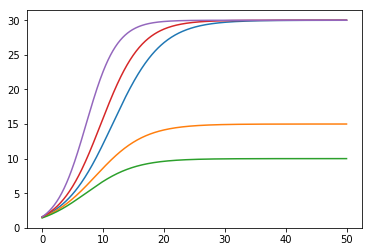

```python
import numpy as np
import matplotlib.pyplot as plt

def make_logistic(r, a, b, c):
    def f_logistic(t):
        return a / (b + c * np.exp(-r * t))
    return f_logistic

r, a, c = 0.25, 30.0, 18.0
b1, b2, b3 = 1.0, 2.0, 3.0
r4, r5 = 0.3, 0.4

logistic1 = make_logistic(r, a, b1, c)
logistic2 = make_logistic(r, a, b2, c)
logistic3 = make_logistic(r, a, b3, c)
logistic4 = make_logistic(r4, a, b1, c)
logistic5 = make_logistic(r5, a, b1, c)

tmax = 50
time_values = np.linspace(0, tmax, 500)

plt.plot(time_values, logistic1(time_values))
plt.plot(time_values, logistic2(time_values))
plt.plot(time_values, logistic3(time_values))
plt.plot(time_values, logistic4(time_values))
plt.plot(time_values, logistic5(time_values))

plt.show()
```

| Symbol string | Line style |
| --- | --- |
| `"-"` | Solid (the default) |
| `"--"` | Dashed |
| `":"` | Dotted |
| `"-."` | Dash-dot |
| `"None"`, `" "`, or `""` | Not displayed |

| marker | description |
| --- | --- |
| `"."` | point |
| `","` | pixel |
| `"o"` | circle |
| `"v"` | triangle_down |
| `"^"` | triangle_up |
| `"<"` | triangle_left |
| `">"` | triangle_right |
| `"1"` | tri_down |
| `"2"` | tri_up |
| `"3"` | tri_left |
| `"4"` | tri_right |
| `"8"` | octagon |
| `"s"` | square |

| Alias | Color |
| --- | --- |
| `"b"` | blue |
| `"g"` | green |
| `"r"` | red |
| `"c"` | cyan |
| `"m"` | magenta |
| `"y"` | yellow |
| `"k"` | black |
| `"w"` | white |

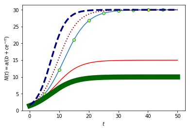

```python
import numpy as np
import matplotlib.pyplot as plt

def make_logistic(r, a, b, c):
    def f_logistic(t):
        return a / (b + c * np.exp(-r * t))
    return f_logistic

r, a, c = 0.25, 30.0, 18.0
b1, b2, b3 = 1.0, 2.0, 3.0
r4, r5 = 0.3, 0.4

logistic1 = make_logistic(r, a, b1, c)
logistic2 = make_logistic(r, a, b2, c)
logistic3 = make_logistic(r, a, b3, c)
logistic4 = make_logistic(r4, a, b1, c)
logistic5 = make_logistic(r5, a, b1, c)

tmax = 50
time_values = np.linspace(0, tmax, 500)

plt.plot(time_values, logistic1(time_values),
         marker = "o",
         markevery = 50,
         markerfacecolor = "GreenYellow")
plt.plot(time_values, logistic2(time_values),
         color = "Red")
plt.plot(time_values, logistic3(time_values),
         linewidth = 10.5,
         color = "DarkGreen",
         linestyle = "-")
plt.plot(time_values, logistic4(time_values),
         linewidth = 2.0,
         color = "#8B0000",
         linestyle = ":")
plt.plot(time_values, logistic5(time_values),
         linewidth = 3.5,
         color = (0.0, 0.0, 0.5),
         linestyle = "--")
plt.xlabel("$t$")
plt.ylabel("$N(t)=a/(b+ce^{-rt})$")

plt.show()
```

# 2. Plot a Logistic (sigmoid) Function

$$\phi(z)=\frac{1}{1+e^{-z}}$$

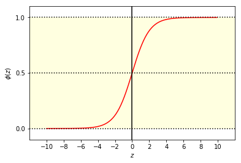

```python
import numpy as np
import matplotlib.pyplot as plt

def sigmoid(z):
    return 1.0 / (1.0 + np.exp(-z))

z = np.arange(-10, 10, 0.1)
phi_z = sigmoid(z)

plt.plot(z, phi_z, color = "r")

# add a vertical line across the x-axis,
# axvline(x = 0, ymin = 0, **kwargs)
plt.axvline(x = 0.0, color = "k")

# add a horizontal span (rectangle) across the y-axis,
# axhspan(ymin, ymax, xmin = 0, xmax = 1, **kwargs)
plt.axhspan(ymin = 0.0, ymax = 1.0, facecolor = "LightYellow", alpha = 1.0, ls = "dotted")

# add horizontal lines across the y-axis
plt.axhline(y = 0.0, ls = "dotted", color = "Black")
plt.axhline(y = 0.5, ls = "dotted", color = "Black")
plt.axhline(y = 1.0, ls = "dotted", color = "Black")

# set the limits of the current tick locations and labels
plt.xticks(np.linspace(-10, 10, 11))
plt.yticks([0.0, 0.5, 1.0])

# set the limits of the x-axis and the y-axis
plt.xlim(-12.0, 12.0)
plt.ylim(-0.1, 1.1)

# set the axis label of the x-axis and the y-axis
plt.xlabel("$z$")
plt.ylabel("$\phi(z)$")

plt.show()
```

# 3. Plot a Pie Chart

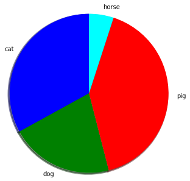

```python
import numpy as np
import matplotlib.pyplot as plt

x = np.array([0.33, 0.21, 0.41, 0.05]) # percentage, sum = 1

plt.pie(x,
        explode = None,
        labels = np.array(["cat", "dog", "pig", "horse"]),
        colors = ("Blue", "Green", "Red", "Cyan"),
        autopct = None,
        pctdistance = 0.6,
        shadow = True,
        labeldistance = 1.1, # distance between label and chart
        startangle = 90,
        radius = 1.5,
        counterclock = True,
        wedgeprops = {"linewidth" : 3},
        textprops = None,
        center = (0, 0),
        frame = False)

plt.show()
```

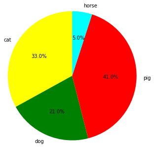

```python
import numpy as np
import matplotlib.pyplot as plt

x = np.array([0.33, 0.21, 0.41, 0.05]) # percentage, sum = 1

plt.pie(x,
        explode = None,
        labels = np.array(["cat", "dog", "pig", "horse"]),
        colors = ("Yellow", "Green", "Red", "Cyan"),
        autopct = "%0.1f%%",
        pctdistance = 0.6,
        #shadow = True,
        labeldistance = 1.1, # distance between label and chart
        startangle = 90,
        radius = 1.5,
        counterclock = True,
        wedgeprops = {"linewidth" : 3},
        textprops = {"color" : "Black"},
        center = (0, 0),
        frame = False)

plt.show()
```

# 4. Plot a Histogram

```
Array x before sorted is [5 7 4 3 3 4 7 4 2 6]
The sorted array x is [2 3 3 4 4 4 5 6 7 7]
```

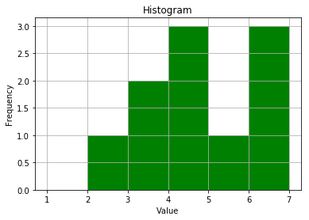

```python
import numpy as np
import matplotlib.pyplot as plt

np.random.seed(80)
x = np.random.randint(1, 8, 10)
print("Array x before sorted is", x)
x.sort()
print("The sorted array x is", x)

plt.hist(x, bins = 6, range = (1, 7), facecolor = "Green", alpha = 1)
plt.xlabel("Value")
plt.ylabel("Frequency")
plt.title("Histogram")
plt.grid(True)

plt.show()
```

# 5. Redo the Previous Linear Regression Coding

## 5.1 Using `curve_fit` from `scipy.optimize`

- `popt`: array, optimal values for the parameters so that the sum of the squared error of `f(xdata, *popt) - ydata` is minimized
- `pcov`: 2d array, the estimated covariance of popt, and the diagonals provide the variance of the parameter estimate

```
The slope of the line is 0.19511494252698092
The intercept of the line is -8.40373563220448
```

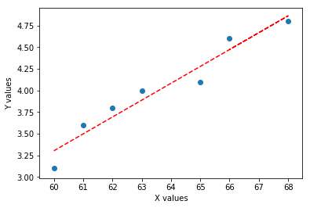

```python
import numpy as np
import matplotlib.pyplot as plt
from scipy.optimize import curve_fit

x = np.array([60, 61, 62, 63, 65, 68, 66])
y = np.array([3.1, 3.6, 3.8, 4.0, 4.1, 4.8, 4.6])

def func(x, a, b):
    return a * x + b

popt, pcov = curve_fit(func, x, y)
print("The slope of the line is", popt[0])
print("The intercept of the line is", popt[1])

Y = func(x, popt[0], popt[1])

plt.plot(x, Y, "r--")
plt.scatter(x, y)
plt.xlabel("X values")
plt.ylabel("Y values")

plt.show()
```

## 5.2 Using `stats` from `scipy`

```
Slope = 0.1951149425287356
Intercept = -8.403735632183905
R_value = 0.9679556241691869
P_value = 0.00034700597994142087
STD_err = 0.022637769810889788
```

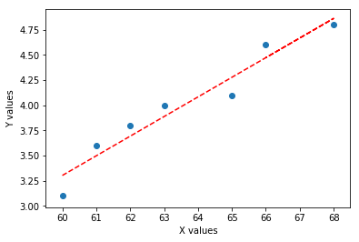

```python
import numpy as np
import matplotlib.pyplot as plt
from scipy import stats

x = np.array([60, 61, 62, 63, 65, 68, 66])
y = np.array([3.1, 3.6, 3.8, 4.0, 4.1, 4.8, 4.6])

slope, intercept, r_value, p_value, std_err = stats.linregress(x, y)
print("Slope =", slope)
print("Intercept =", intercept)
print("R_value =", r_value)
print("P_value =", p_value)
print("STD_err =", std_err)

line = intercept + slope * x

plt.plot(x, line, "r--")
plt.scatter(x, y)
plt.xlabel("X values")
plt.ylabel("Y values")

plt.show()
```

# 6. An Application of NumPy Arrays in Linear Algebra

NumPy arrays do not behave like matrices in linear algebra by default

You can use the built-in `numpy.dot()` and `numpy.linalg.inv()` functions, or you can use the `numpy.matrix()` object instead

$$\begin{align} 3x+6y-5z&=12\\ x-3y+2z&=-2\\ 5x-y+4z&=10 \end{align}$$$$\underset{A}{\left[\begin{array}{c}3&6&-5\\1&-3&2\\5&-1&4\end{array}\right]}\underset{\textbf{x}}{\left[\begin{array}{c}x\\y\\z\end{array}\right]}=\underset{\textbf{b}}{\left[\begin{array}{c}12\\-2\\10\end{array}\right]}$$$$\textbf{x}=A^{-1}\textbf{b}$$

```python
import numpy as np

A = np.array([[3, 6, -5],
              [1, -3, 2],
              [5, -1, 4]])
b = np.array([12, -2, 10])

x = np.linalg.inv(A).dot(b)

print("x =", round(x[0], 2))
print("y =", round(x[1], 2))
print("z =", round(x[2], 2))
```

```
x = 1.75
y = 1.75
z = 0.75
```

```python
import numpy as np

A = np.array([[3, 6, -5],
              [1, -3, 2],
              [5, -1, 4]])
A_mat = np.matrix(A)
b_mat = np.matrix([[12],
                   [-2],
                   [10]])
x = A_mat**(-1) * b_mat

print("x =", round(x[0, 0], 2))
print("y =", round(x[1, 0], 2))
print("z =", round(x[2, 0], 2))
```

```
x = 1.75
y = 1.75
z = 0.75
```

# 7. An Example of Using NumPy, SciPy and Matplotlib in 3D Plotting

The **Lorenz system** is a system of ordinary differential equations first studied by Edward Lorenz

It is notable for having chaotic solutions for certain parameter values and initial conditions

## 7.1 Single Graph in One Plot

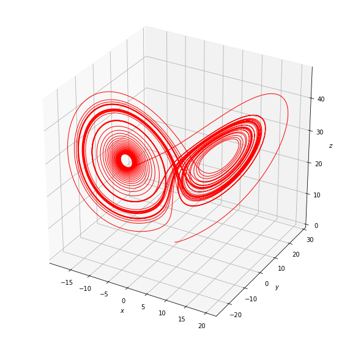

```python
import numpy as np
import matplotlib.pyplot as plt
from scipy.integrate import odeint
from mpl_toolkits.mplot3d import Axes3D

def make_lorenz(sigma, rho, beta):
    def func(statevec, t):
        x, y, z = statevec
        return [sigma * (y - x),
                rho * x - y - x * z,
                x * y - beta * z]
    return func

lorenz_eq = make_lorenz(10.0, 28.0, 8.0/3.0) # common: 10, 8/3

tmax = 50
tdelta = 0.005
tvalues = np.arange(0, tmax, tdelta)
ic = np.array([0.0, 1.0, 0.0])
sol = odeint(lorenz_eq, ic, tvalues)

x, y, z = np.array(list(zip(*sol))) # unzip the list to three single values

fig = plt.figure(figsize = (10, 10))
ax = fig.add_subplot(111, projection = "3d")
ax.plot(x, y, z, lw = 1, color = "red")
ax.set_xlabel("$x$")
ax.set_ylabel("$y$")
ax.set_zlabel("$z$")

plt.show()
```

## 7.2 Two Graphs in One Plot

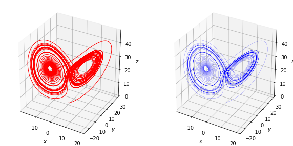

```python
import numpy as np
import matplotlib.pyplot as plt
from scipy.integrate import odeint
from mpl_toolkits.mplot3d import Axes3D

def make_lorenz(sigma, rho, beta):
    def func(statevec, t):
        x, y, z = statevec
        return [sigma * (y - x),
                rho * x - y - x * z,
                x * y - beta * z]
    return func

lorenz_eq = make_lorenz(10.0, 28.0, 8.0/3.0) # common: 10, 8/3

tmax = 50
tdelta = 0.005
tvalues = np.arange(0, tmax, tdelta)
ic = np.array([0.0, 1.0, 0.0])
sol = odeint(lorenz_eq, ic, tvalues)

x, y, z = np.array(list(zip(*sol))) # unzip the list to three single values

fig = plt.figure(figsize = (10, 5))
ax1 = fig.add_subplot(121, projection = "3d")
ax1.plot(x, y, z, lw = 1, color = "red")
ax1.set_xlabel("$x$")
ax1.set_ylabel("$y$")
ax1.set_zlabel("$z$")
ax2 = fig.add_subplot(122, projection = "3d")
ax2.plot(x, y, z, lw = 0.2, color = "blue")
ax2.set_xlabel("$x$")
ax2.set_ylabel("$y$")
ax2.set_zlabel("$z$")

plt.show()
```

## 7.3 Four Graphs in One Plot

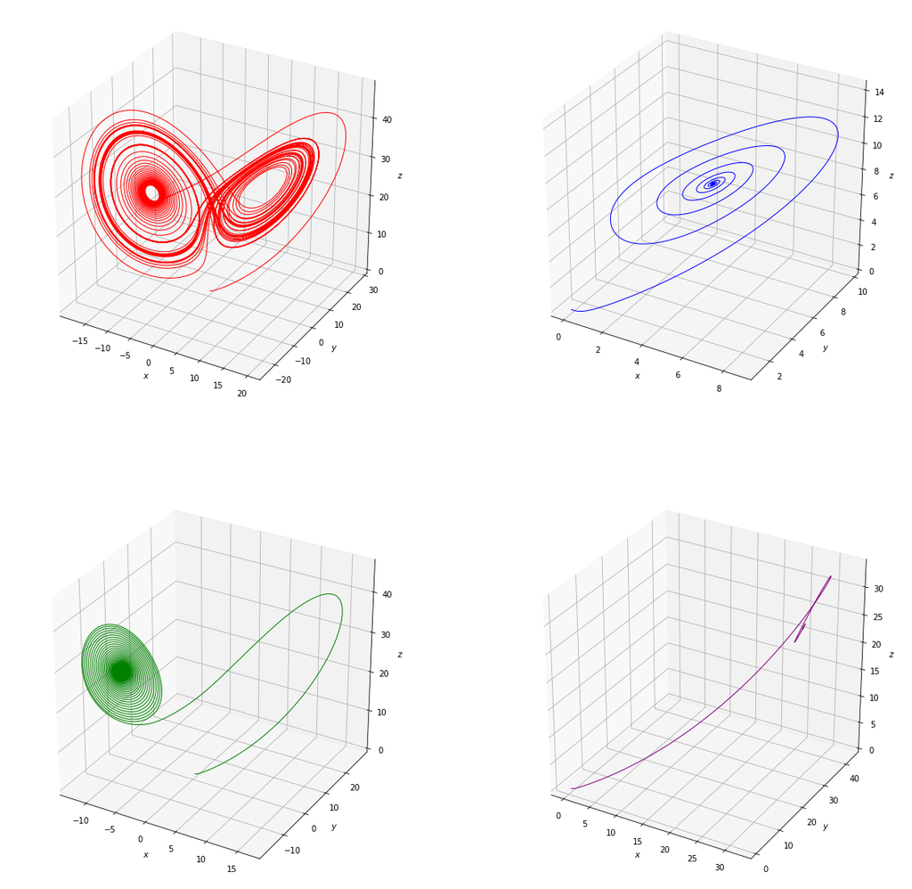

```python
import numpy as np
import matplotlib.pyplot as plt
from scipy.integrate import odeint
from mpl_toolkits.mplot3d import Axes3D

def make_lorenz(sigma, rho, beta):
    def func(statevec, t):
        x, y, z = statevec
        return [sigma * (y - x),
                rho * x - y - x * z,
                x * y - beta * z]
    return func

# create a set of Lorenz equitions
lorenz_eq1 = make_lorenz(10.0, 28.0, 8.0/3.0)
lorenz_eq2 = make_lorenz(10.0, 10.0, 8.0/3.0)
lorenz_eq3 = make_lorenz(5.0, 28.0, 8.0/3.0)
lorenz_eq4 = make_lorenz(10.0, 28.0, 100.0/3.0)

tmax = 50
tdelta = 0.005
tvalues = np.arange(0, tmax, tdelta)
ic = np.array([0.0, 1.0, 0.0])
sol1 = odeint(lorenz_eq1, ic, tvalues)
sol2 = odeint(lorenz_eq2, ic, tvalues)
sol3 = odeint(lorenz_eq3, ic, tvalues)
sol4 = odeint(lorenz_eq4, ic, tvalues)

x1, y1, z1 = np.array(list(zip(*sol1)))
x2, y2, z2 = np.array(list(zip(*sol2)))
x3, y3, z3 = np.array(list(zip(*sol3)))
x4, y4, z4 = np.array(list(zip(*sol4)))

fig = plt.figure(figsize = (20, 20))
ax1 = fig.add_subplot(221, projection = "3d")
ax1.plot(x1, y1, z1, lw = 1, color = "red")
ax1.set_xlabel("$x$")
ax1.set_ylabel("$y$")
ax1.set_zlabel("$z$")
ax2 = fig.add_subplot(222, projection = "3d")
ax2.plot(x2, y2, z2, lw = 1, color = "blue")
ax2.set_xlabel("$x$")
ax2.set_ylabel("$y$")
ax2.set_zlabel("$z$")
ax3 = fig.add_subplot(223, projection = "3d")
ax3.plot(x3, y3, z3, lw = 1, color = "green")
ax3.set_xlabel("$x$")
ax3.set_ylabel("$y$")
ax3.set_zlabel("$z$")
ax4 = fig.add_subplot(224, projection = "3d")
ax4.plot(x4, y4, z4, lw = 1, color = "purple")
ax4.set_xlabel("$x$")
ax4.set_ylabel("$y$")
ax4.set_zlabel("$z$")

plt.show()
```

## 7.4 The Lorenz Equations

Edward Lorenz developed a simplified mathematical model for atmospheric convection

The model is a system of three ordinary differential equations now known as the Lorenz equations:

$$\begin{align} \frac{\text{d}x}{\text{d}t}&=\sigma(y-x)\\ \frac{\text{d}y}{\text{d}t}&=x(\rho-z)-y\\ \frac{\text{d}z}{\text{d}t}&=xy-\beta z \end{align}$$

# 8. Cluster Plotting

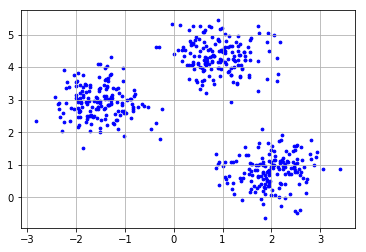

```python
import matplotlib.pyplot as plt
from sklearn.datasets import make_blobs

# generate an array of samples X of shape[n_sample, n_features]
# y, an array of integer labels for cluster membership of each sample
X, y = make_blobs(n_samples = 500,
                  centers = 3, # number of centers to generate
                  cluster_std = 0.5, # standard deviation of the clusters
                  shuffle = True,
                  random_state = 0) # the seed used by the random number generator

plt.scatter(X[:, 0],
            X[:, 1],
            c = "blue",
            marker = ".",
            s = 30)
plt.grid()
plt.show()
```

# 9. Cluster Analysis: K-Means

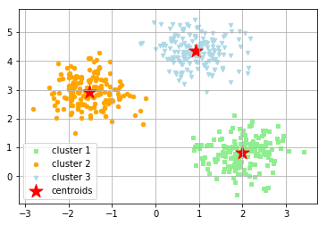

```python
import matplotlib.pyplot as plt
from sklearn.datasets import make_blobs
from sklearn.cluster import KMeans

X, y = make_blobs(n_samples = 500,
                  n_features = 2,
                  centers = 3,
                  cluster_std = 0.5,
                  shuffle = True,
                  random_state = 0)

km = KMeans(n_clusters = 3,
            init = "random",
            n_init = 10,
            max_iter = 300,
            tol = 1e-04,
            random_state = 0)
y_km = km.fit_predict(X)

plt.scatter(X[y_km == 0, 0],
            X[y_km == 0, 1],
            s = 20,
            c = "lightgreen",
            marker = "s",
            label = "cluster 1")
plt.scatter(X[y_km == 1, 0],
            X[y_km == 1, 1],
            s = 20,
            c = "orange",
            marker = "o",
            label = "cluster 2")
plt.scatter(X[y_km == 2, 0],
            X[y_km == 2, 1],
            s = 20,
            c = "lightblue",
            marker = "v",
            label = "cluster 3")
plt.scatter(km.cluster_centers_[:, 0],
            km.cluster_centers_[:, 1],
            s = 250,
            marker = "*",
            c = "red",
            label = "centroids")

plt.legend(loc = 3)
plt.grid()
plt.show()
```

## 9.1 Cluster Plotting from a Data File

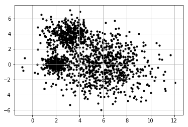

```python
import numpy as np
import matplotlib.pyplot as plt

readin = open(r"C:\Users\Harry Lu's X1\Documents\Cornell\STSCI 4060 - Python\unequal.txt")
lx = []
ly = []
for aline in readin:
    splits = aline.split()
    lx.append(splits[1])
    ly.append(splits[2])

x = np.array(lx).astype(float)
y = np.array(ly).astype(float)

plt.scatter(x, y, c = "black", marker = "o", s = 10)
plt.grid()
plt.show()
```

## 9.2 Improved Cluster Plotting

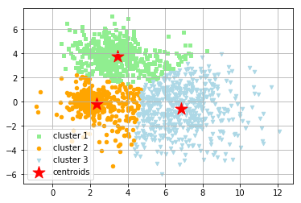

```python
import numpy as np
import matplotlib.pyplot as plt
from sklearn.cluster import KMeans

readin = open(r"C:\Users\Harry Lu's X1\Documents\Cornell\STSCI 4060 - Python\unequal.txt")
lx = []
ly = []
for aline in readin:
    splits = aline.split()
    lx.append(splits[1])
    ly.append(splits[2])
lengthList = len(lx)

x = np.array(lx).astype(float)
y = np.array(ly).astype(float)
X = np.empty((lengthList, 2))
X[:, 0] = x
X[:, 1] = y

km = KMeans(n_clusters = 3,
            init = "random",
            n_init = 10,
            max_iter = 300,
            tol = 1e-04,
            random_state = 0)
y_km = km.fit_predict(X)

plt.scatter(X[y_km == 0, 0],
            X[y_km == 0, 1],
            s = 20,
            c = "lightgreen",
            marker = "s",
            label = "cluster 1")
plt.scatter(X[y_km == 1, 0],
            X[y_km == 1, 1],
            s = 20,
            c = "orange",
            marker = "o",
            label = "cluster 2")
plt.scatter(X[y_km == 2, 0],
            X[y_km == 2, 1],
            s = 20,
            c = "lightblue",
            marker = "v",
            label = "cluster 3")
plt.scatter(km.cluster_centers_[:, 0],
            km.cluster_centers_[:, 1],
            s = 250,
            marker = "*",
            c = "red",
            label = "centroids")

plt.legend(loc = 3)
plt.grid()
plt.show()
```